# MTG_sep2026_models

anonymous

2026-09-23

```r
library (tidyverse)
```

Read data and create variables

```r
data <- read_csv("mtg_sep26.csv", skip_empty_rows = TRUE)
## create gap columns by subtracting from quest_tend

data <- data %>%
  mutate(
    combined_gap    = combined    - quest_tend,
    viable_gap      = viable      - quest_tend,
    verbal_gap      = verbal      - quest_tend,
    vocal_gap       = vocal_start - quest_tend,
    vegetative_gap  = vegetative  - quest_tend,
    visual_gap      = visual      - quest_tend
  )


## for ease of script re-use:
 timedata <- data
```

# Bayesian inferential modelling - VISUAL cues

```r
### BAYESIAN MODEL for visual ---------

## setup --------


# package for Bayesian regression modeling
library(brms)
# package for visualization
library(tidybayes)
```

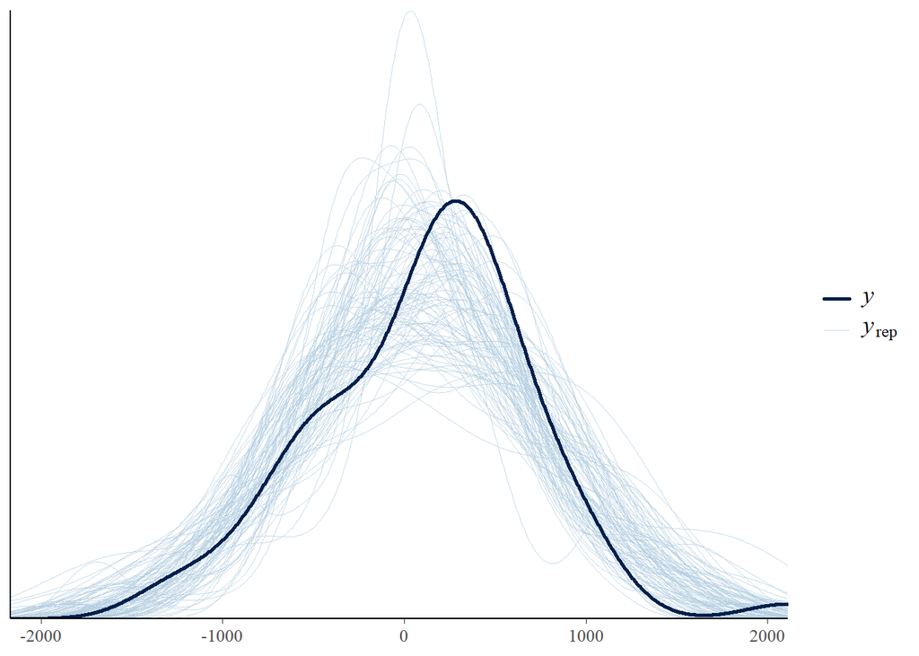

```r
# package to visualize
library(bayesplot)
# make Stan run faster
options(mc.cores = parallel::detectCores())

# use cmdstanr (with caution!)
#options(brms.backend = "cmdstanr")

# to change back;
# options(brms.backend = "rstan")






## Full model  --------------------------------



## set weakly informative prior

priors_model1 <- c(
  set_prior("normal (0,1000)", class = "b"),
  set_prior("normal (0,6000)", class = "Intercept")
)





## Model1 - NOTE ex-gaussian does NOT work with this data set (not easily at all anyway)



model_visual = brm(
  visual_gap ~ proficiency*qType + (1+qType|file) + (1|quest_label),
  prior = priors_model1,
  data = data,
  iter = 4000, warmup = 2000,
  family = gaussian(),
  control = list(adapt_delta = 0.99),
  seed = 55,
  file = "interaction_visual"
)


## posterior predictive check

pp_check (model_visual, nsamples = 100)
```

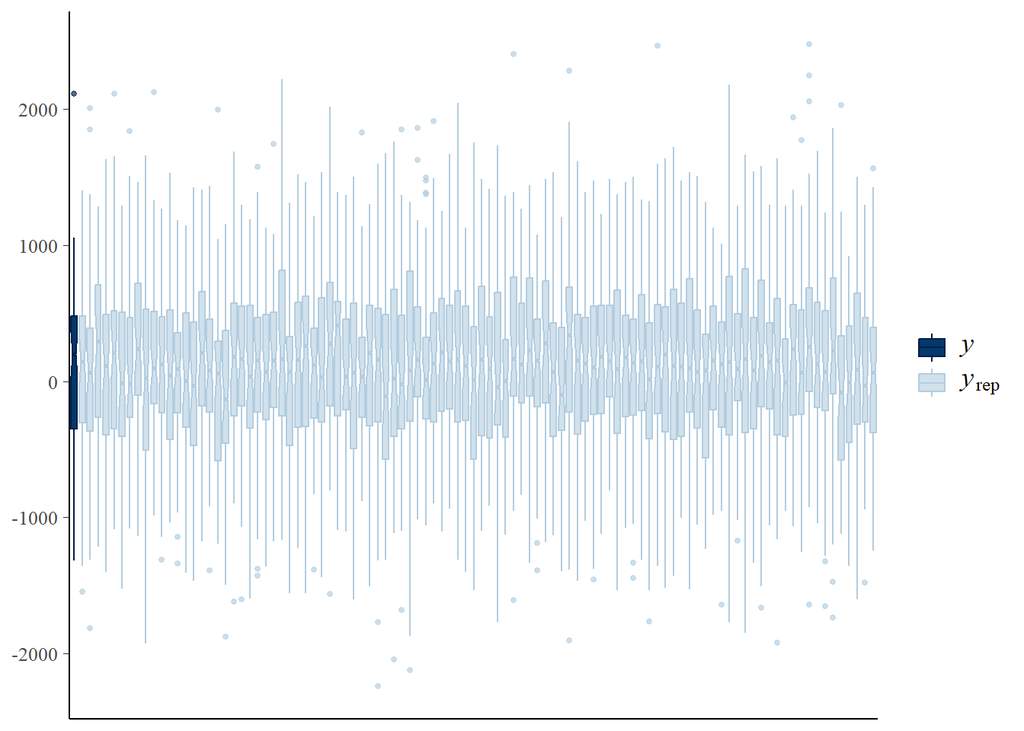

```r
pp_check (model_visual, nsamples = 100, type = "boxplot")
```

```r
##### more pp checks

# Extract 100 posterior predictive draws for all observations
yrep <- posterior_predict(model_visual, nsamples = 100)
# Calculate mean and sd of observed data
mean_obs <- mean(timedata$visual_gap, na.rm=TRUE)
sd_obs <- sd(timedata$visual_gap, na.rm=TRUE)

# Calculate mean and sd for each posterior predictive draw
mean_pred <- apply(yrep, 1, mean)
sd_pred <- apply(yrep, 1, sd)

# Summarize means and SDs of predictions
summary_means <- summary(mean_pred)
summary_sds <- summary(sd_pred)
```

```r
# Print summaries
print("Observed Data:")
```

```
## [1] "Observed Data:"
```

```r
print(paste("Mean:", round(mean_obs, 2), "SD:", round(sd_obs, 2)))
```

```
## [1] "Mean: 114.26 SD: 600.44"
```

```r
print("Posterior Predictive Means:")
```

```
## [1] "Posterior Predictive Means:"
```

```r
print(summary_means)
```

```
##    Min. 1st Qu.  Median    Mean 3rd Qu.    Max.
## -117.09   56.11  115.01  115.61  181.62  378.58
```

```r
print("Posterior Predictive SDs:")
```

```
## [1] "Posterior Predictive SDs:"
```

```r
print(summary_sds)
```

```
##    Min. 1st Qu.  Median    Mean 3rd Qu.    Max.
##   446.8   566.3   619.4   620.1   666.1   860.0
```

```r
# Optional: check skewness difference
if(!require(moments)) install.packages("moments")
library(moments)

skew_obs <- skewness(timedata$visual_gap, na.rm=TRUE)
skew_pred <- apply(yrep, 1, skewness)
summary_skew_pred <- summary(skew_pred)

print(paste("Observed skewness:", round(skew_obs, 3)))
```

```
## [1] "Observed skewness: 0.068"
```

```r
print("Posterior Predictive Skewness:")
```

```
## [1] "Posterior Predictive Skewness:"
```

```r
print(summary_skew_pred)
```

```
##     Min.  1st Qu.   Median     Mean  3rd Qu.     Max.
## -0.62070 -0.16400  0.01961  0.02616  0.20199  1.15519
```

```r
###------

summary (model_visual)
```

```
##  Family: gaussian
##   Links: mu = identity
## Formula: visual_gap ~ proficiency * qType + (1 + qType | file) + (1 | quest_label)
##    Data: data (Number of observations: 65)
##   Draws: 4 chains, each with iter = 4000; warmup = 2000; thin = 1;
##          total post-warmup draws = 8000
##
## Multilevel Hyperparameters:
## ~file (Number of levels: 24)
##                           Estimate Est.Error l-95% CI u-95% CI Rhat Bulk_ESS
## sd(Intercept)               235.22    127.19    18.07   503.29 1.00     1931
## sd(qTypePolar)              161.24    124.91     5.34   464.97 1.00     2792
## cor(Intercept,qTypePolar)    -0.19      0.57    -0.97     0.91 1.00     5790
##                           Tail_ESS
## sd(Intercept)                 2770
## sd(qTypePolar)                2903
## cor(Intercept,qTypePolar)     5463
##
## ~quest_label (Number of levels: 4)
##               Estimate Est.Error l-95% CI u-95% CI Rhat Bulk_ESS Tail_ESS
## sd(Intercept)   207.73    188.16     8.30   684.11 1.00     2488     3261
##
## Regression Coefficients:
##                                    Estimate Est.Error l-95% CI u-95% CI Rhat
## Intercept                            388.64    252.80  -112.76   871.65 1.00
## proficiencyIntermediate             -601.78    215.99 -1018.87  -172.32 1.00
## qTypePolar                          -116.54    309.12  -715.94   521.97 1.00
## proficiencyIntermediate:qTypePolar   449.62    261.81   -55.21   971.67 1.00
##                                    Bulk_ESS Tail_ESS
## Intercept                              3975     3718
## proficiencyIntermediate                5842     6194
## qTypePolar                             3944     3553
## proficiencyIntermediate:qTypePolar     6204     5546
##
## Further Distributional Parameters:
##       Estimate Est.Error l-95% CI u-95% CI Rhat Bulk_ESS Tail_ESS
## sigma   511.97     57.37   409.78   635.58 1.00     4028     5542
##
## Draws were sampled using sampling(NUTS). For each parameter, Bulk_ESS
## and Tail_ESS are effective sample size measures, and Rhat is the potential
## scale reduction factor on split chains (at convergence, Rhat = 1).
```

Family: gaussian Links: mu = identity Formula: visual_gap ~ proficiency * qType + (1 + qType | file) + (1 | quest_label) Data: data (Number of observations: 65) Draws: 4 chains, each with iter = 4000; warmup = 2000; thin = 1; total post-warmup draws = 8000

Draws were sampled using sampling(NUTS). For each parameter, Bulk_ESS and Tail_ESS are effective sample size measures, and Rhat is the potential scale reduction factor on split chains (at convergence, Rhat = 1).

```r
## Posteriors across tasks

posterior_samples <- posterior_samples(model_visual)
# Calculate the group effect for each task
group_effect_open <- posterior_samples$b_proficiencyIntermediate
group_effect_polar <- posterior_samples$b_proficiencyIntermediate + posterior_samples$`b_proficiencyIntermediate:qTypePolar`

# Step 2: Calculate the overall group difference across all tasks by averaging
overall_group_diff_across_tasks <- (group_effect_open + group_effect_polar) / 2

# Step 3: Define custom summary function
summary_stats <- function(samples) {
  mean_val <- mean(samples)
  lower <- quantile(samples, 0.025)
  upper <- quantile(samples, 0.975)
  prob_above_zero <- mean(samples > 0)
  data.frame(mean = mean_val, lower_95CrI = lower, upper_95CrI = upper, posterior_prob = prob_above_zero)
}

# Step 4: Calculate summary statistics for the overall group difference
results <- summary_stats(overall_group_diff_across_tasks)

results$posterior_prob_flipped <- 1 - results$posterior_prob

print (results)
```

```
##           mean lower_95CrI upper_95CrI posterior_prob posterior_prob_flipped
## 2.5% -376.9669   -703.8009    -40.4225       0.014125               0.985875
```

## RESULTS:

```
mean lower_95CrI upper_95CrI posterior_prob posterior_prob_flipped
```

2.5% -376.9669 -703.8009 -40.4225 0.014125 0.985875

```r
### Posteriors by task



# Calculate summary statistics for each task
results <- list(
  Polar = summary_stats(group_effect_polar),
  Open = summary_stats(group_effect_open)
)



# View the results
print(results)
```

```
## $Polar
##           mean lower_95CrI upper_95CrI posterior_prob
## 2.5% -152.1577   -559.1034    257.5942       0.232125
##
## $Open
##           mean lower_95CrI upper_95CrI posterior_prob
## 2.5% -601.7761   -1018.865   -172.3222         0.0035
```

```r
#
```

$Polar mean lower_95CrI upper_95CrI posterior_prob 2.5% -152.1577 -559.1034 257.5942 0.232125

$Open mean lower_95CrI upper_95CrI posterior_prob 2.5% -601.7761 -1018.865 -172.3222 0.0035

```r
## QType comparison (open vs polar)

# qType effects by proficiency
qt_beginner <- posterior_samples$b_qTypePolar
qt_intermediate <- posterior_samples$b_qTypePolar + posterior_samples$`b_proficiencyIntermediate:qTypePolar`


results <- list(
  Beginner = summary_stats(qt_beginner),
  Intermediate = summary_stats(qt_intermediate))

print (results)
```

```
## $Beginner
##           mean lower_95CrI upper_95CrI posterior_prob
## 2.5% -116.5429   -715.9443    521.9693        0.32325
##
## $Intermediate
##          mean lower_95CrI upper_95CrI posterior_prob
## 2.5% 333.0755   -241.5314     977.373       0.898375
```

$Beginner mean lower_95CrI upper_95CrI posterior_prob 2.5% -116.5429 -715.9443 521.9693 0.32325

$Intermediate mean lower_95CrI upper_95CrI posterior_prob 2.5% 333.0755 -241.5314 977.373 0.898375

```r
# question effect across groups (averaged)


overall_question <- (qt_beginner + qt_intermediate) / 2


results <- summary_stats (overall_question)

results$posterior_prob_flipped <- 1 - results$posterior_prob

print (results)
```

```
##          mean lower_95CrI upper_95CrI posterior_prob posterior_prob_flipped
## 2.5% 108.2663    -415.567    702.7833        0.68075                0.31925
```

mean lower_95CrI upper_95CrI posterior_prob posterior_prob_flipped 2.5% 108.2663 -415.567 702.7833 0.68075 0.31925

```r
# Interaction effect proficiency*QType

interaction_effect <- posterior_samples$`b_proficiencyIntermediate:qTypePolar`

# Summary
results <- summary_stats(interaction_effect)

results$posterior_prob_flipped <- 1 - results$posterior_prob

print(results)
```

```
##          mean lower_95CrI upper_95CrI posterior_prob posterior_prob_flipped
## 2.5% 449.6184   -55.20549    971.6661        0.96125                0.03875
```

```
 mean lower_95CrI upper_95CrI posterior_prob posterior_prob_flipped
```

2.5% 449.6184 -55.20549 971.6661 0.96125 0.03875

# Bayesian inferential modelling - COMBINED (verbal + viable) cues

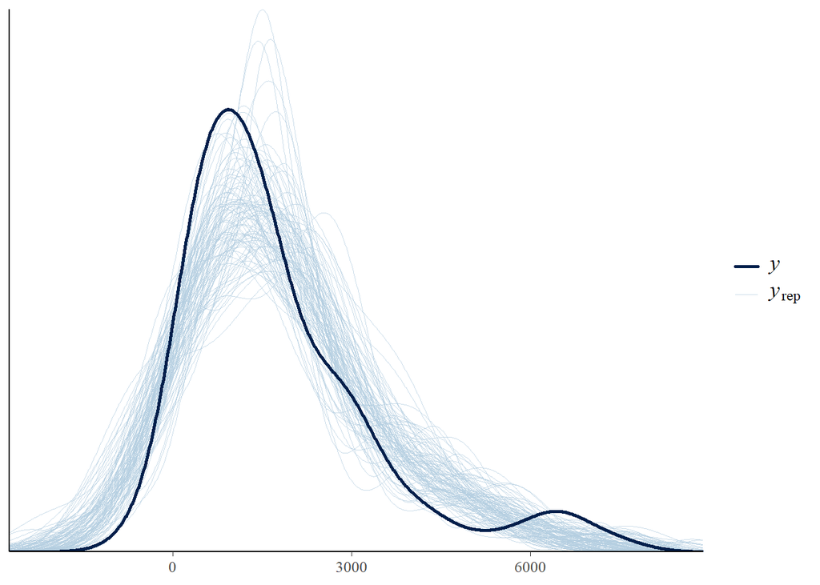

```r
### BAYESIAN MODEL for combined (verbal and viable) ----------

## setup --------


# package for Bayesian regression modeling
library(brms)

# package for visualization
library(tidybayes)

# package to visualize
library(bayesplot)

# make Stan run faster
options(mc.cores = parallel::detectCores())

# use cmdstanr (with caution!)
#options(brms.backend = "cmdstanr")

# to change back;
# options(brms.backend = "rstan")





## Gaussian instead of exGaussian due to limited data



## Full model  --------------------------------



## set weakly informative prior

priors_model1 <- c(
  set_prior("normal (0,1000)", class = "b"),
  set_prior("normal (0,6000)", class = "Intercept")
)





## Model1



model1 = brm(
  combined_gap ~ proficiency*qType + (1+qType|file) + (1|quest_label),
  prior = priors_model1,
  data = data,
  iter = 4000, warmup = 2000,
  family = gaussian(),
  control = list(adapt_delta = 0.99),
  seed = 55,
  file = "m1_full_interaction"
)


## posterior predictive check

pp_check (model1, nsamples = 100)
```

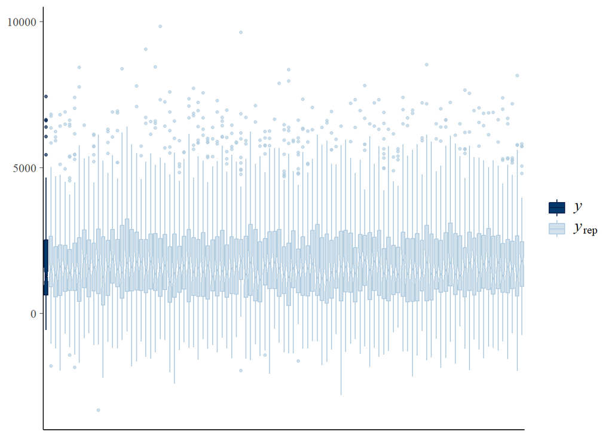

```r
pp_check (model1, nsamples = 100, type = "boxplot")
```

```r
##### more pp checks

# Extract 100 posterior predictive draws for all observations
yrep <- posterior_predict(model1, nsamples = 100)
# Calculate mean and sd of observed data
mean_obs <- mean(timedata$combined_gap, na.rm=TRUE)
sd_obs <- sd(timedata$combined_gap, na.rm=TRUE)

# Calculate mean and sd for each posterior predictive draw
mean_pred <- apply(yrep, 1, mean)
sd_pred <- apply(yrep, 1, sd)

# Summarize means and SDs of predictions
summary_means <- summary(mean_pred)
summary_sds <- summary(sd_pred)

# Print summaries
print("Observed Data:")
```

```
## [1] "Observed Data:"
```

```r
print(paste("Mean:", round(mean_obs, 2), "SD:", round(sd_obs, 2)))
```

```
## [1] "Mean: 1776.31 SD: 1610.79"
```

```r
print("Posterior Predictive Means:")
```

```
## [1] "Posterior Predictive Means:"
```

```r
print(summary_means)
```

```
##    Min. 1st Qu.  Median    Mean 3rd Qu.    Max.
##    1483    1698    1771    1784    1884    2149
```

```r
print("Posterior Predictive SDs:")
```

```
## [1] "Posterior Predictive SDs:"
```

```r
print(summary_sds)
```

```
##    Min. 1st Qu.  Median    Mean 3rd Qu.    Max.
##    1417    1537    1624    1623    1696    2067
```

```r
# Optional: check skewness difference
if(!require(moments)) install.packages("moments")
library(moments)

skew_obs <- skewness(timedata$combined_gap, na.rm = TRUE)
skew_pred <- apply(yrep, 1, skewness)
summary_skew_pred <- summary(skew_pred)

print(paste("Observed skewness:", round(skew_obs, 3)))
```

```
## [1] "Observed skewness: 1.578"
```

```r
print("Posterior Predictive Skewness:")
```

```
## [1] "Posterior Predictive Skewness:"
```

```r
print(summary_skew_pred)
```

```
##    Min. 1st Qu.  Median    Mean 3rd Qu.    Max.
## 0.08123 0.68520 0.82940 0.82541 0.99159 1.47677
```

```r
###------

summary (model1)
```

```
##  Family: gaussian
##   Links: mu = identity
## Formula: combined_gap ~ proficiency * qType + (1 + qType | file) + (1 | quest_label)
##    Data: data (Number of observations: 96)
##   Draws: 4 chains, each with iter = 4000; warmup = 2000; thin = 1;
##          total post-warmup draws = 8000
##
## Multilevel Hyperparameters:
## ~file (Number of levels: 24)
##                           Estimate Est.Error l-95% CI u-95% CI Rhat Bulk_ESS
## sd(Intercept)              1387.86    237.84   977.71  1912.19 1.00     2214
## sd(qTypePolar)             1232.16    260.90   764.29  1791.58 1.00     2880
## cor(Intercept,qTypePolar)    -0.96      0.04    -1.00    -0.84 1.00     4167
##                           Tail_ESS
## sd(Intercept)                 4051
## sd(qTypePolar)                4335
## cor(Intercept,qTypePolar)     3896
##
## ~quest_label (Number of levels: 4)
##               Estimate Est.Error l-95% CI u-95% CI Rhat Bulk_ESS Tail_ESS
## sd(Intercept)   760.60    489.75   187.91  2002.46 1.00     2572     3700
##
## Regression Coefficients:
##                                    Estimate Est.Error l-95% CI u-95% CI Rhat
## Intercept                           2397.96    644.28  1001.63  3564.33 1.00
## proficiencyIntermediate             -283.13    483.56 -1208.79   689.09 1.00
## qTypePolar                          -996.34    707.74 -2250.15   582.98 1.00
## proficiencyIntermediate:qTypePolar   -53.41    486.99 -1020.85   880.20 1.00
##                                    Bulk_ESS Tail_ESS
## Intercept                              3161     3797
## proficiencyIntermediate                2566     4194
## qTypePolar                             3849     5136
## proficiencyIntermediate:qTypePolar     3349     4821
##
## Further Distributional Parameters:
##       Estimate Est.Error l-95% CI u-95% CI Rhat Bulk_ESS Tail_ESS
## sigma   880.68     82.21   734.88  1056.85 1.00     4876     5473
##
## Draws were sampled using sampling(NUTS). For each parameter, Bulk_ESS
## and Tail_ESS are effective sample size measures, and Rhat is the potential
## scale reduction factor on split chains (at convergence, Rhat = 1).
```

```r
# #
```

Family: gaussian Links: mu = identity Formula: combined_gap ~ proficiency * qType + (1 + qType | file) + (1 | quest_label) Data: data (Number of observations: 96) Draws: 4 chains, each with iter = 4000; warmup = 2000; thin = 1; total post-warmup draws = 8000

Multilevel Hyperparameters: ~file (Number of levels: 24) Estimate Est.Error l-95% CI u-95% CI Rhat Bulk_ESS Tail_ESS sd(Intercept) 1387.86 237.84 977.71 1912.19 1.00 2214 4051 sd(qTypePolar) 1232.16 260.90 764.29 1791.58 1.00 2880 4335 cor(Intercept,qTypePolar) -0.96 0.04 -1.00 -0.84 1.00 4167 3896

~quest_label (Number of levels: 4) Estimate Est.Error l-95% CI u-95% CI Rhat Bulk_ESS Tail_ESS sd(Intercept) 760.60 489.75 187.91 2002.46 1.00 2572 3700

Regression Coefficients: Estimate Est.Error l-95% CI u-95% CI Rhat Bulk_ESS Tail_ESS Intercept 2397.96 644.28 1001.63 3564.33 1.00 3161 3797 proficiencyIntermediate -283.13 483.56 -1208.79 689.09 1.00 2566 4194 qTypePolar -996.34 707.74 -2250.15 582.98 1.00 3849 5136 proficiencyIntermediate:qTypePolar -53.41 486.99 -1020.85 880.20 1.00 3349 4821

Further Distributional Parameters: Estimate Est.Error l-95% CI u-95% CI Rhat Bulk_ESS Tail_ESS sigma 880.68 82.21 734.88 1056.85 1.00 4876 5473

Draws were sampled using sampling(NUTS). For each parameter, Bulk_ESS and Tail_ESS are effective sample size measures, and Rhat is the potential scale reduction factor on split chains (at convergence, Rhat = 1).

summary (model1)

```r
posterior_samples <- posterior_samples(model1)
# Step 1: Calculate the group effect for each task
group_effect_open <- posterior_samples$b_proficiencyIntermediate
group_effect_polar <- posterior_samples$b_proficiencyIntermediate + posterior_samples$`b_proficiencyIntermediate:qTypePolar`

# Step 2: Calculate the overall group difference across all tasks by averaging
overall_group_diff_across_tasks <- (group_effect_open + group_effect_polar) / 2

# Step 3: Define custom summary function
summary_stats <- function(samples) {
  mean_val <- mean(samples)
  lower <- quantile(samples, 0.025)
  upper <- quantile(samples, 0.975)
  prob_above_zero <- mean(samples > 0)
  prob_below_zero <- 1 - prob_above_zero
  evidence_ratio1 <- prob_above_zero / prob_below_zero
  evidence_ratio2 <- prob_below_zero / prob_above_zero
  data.frame(mean = mean_val, lower_95CrI = lower, upper_95CrI = upper, posterior_prob = prob_above_zero, ER1 = evidence_ratio1, ER2 = evidence_ratio2)
}

# Step 4: Calculate summary statistics for the overall group difference
results <- summary_stats(overall_group_diff_across_tasks)

results$posterior_prob_flipped <- 1 - results$posterior_prob

print (results)
```

```
##           mean lower_95CrI upper_95CrI posterior_prob       ER1      ER2
## 2.5% -309.8345   -938.0307    328.8906       0.167125 0.2006604 4.983545
##      posterior_prob_flipped
## 2.5%               0.832875
```

## RESULTS: Overall effect of proficiency

mean lower_95CrI upper_95CrI posterior_prob ER1 ER2 posterior_prob_flipped 2.5% -309.8345 -938.0307 328.8906 0.167125 0.2006604 4.983545 0.832875

```r
## group effect open questions only

results <- summary_stats(group_effect_open)

results$posterior_prob_flipped <- 1 - results$posterior_prob

print (results)
```

```
##          mean lower_95CrI upper_95CrI posterior_prob       ER1      ER2
## 2.5% -283.128   -1208.792    689.0944       0.273125 0.3757524 2.661327
##      posterior_prob_flipped
## 2.5%               0.726875
```

mean lower_95CrI upper_95CrI posterior_prob ER1 ER2 posterior_prob_flipped 2.5% -283.128 -1208.792 689.0944 0.273125 0.3757524 2.661327 0.726875

```r
## group effect polar questions only

results <- summary_stats(group_effect_polar)

results$posterior_prob_flipped <- 1 - results$posterior_prob

print (results)
```

```
##           mean lower_95CrI upper_95CrI posterior_prob      ER1    ER2
## 2.5% -336.5409    -933.938    265.5146          0.128 0.146789 6.8125
##      posterior_prob_flipped
## 2.5%                  0.872
```

mean lower_95CrI upper_95CrI posterior_prob ER1 ER2 posterior_prob_flipped 2.5% -336.5409 -933.938 265.5146 0.128 0.146789 6.8125 0.872

```r
### Posteriors for group effect by question type (open vs polar)


# Calculate summary statistics for each task
results <- list(
  Polar = summary_stats(group_effect_polar),
  Open = summary_stats(group_effect_open)
)



# View the results
print(results)
```

```
## $Polar
##           mean lower_95CrI upper_95CrI posterior_prob      ER1    ER2
## 2.5% -336.5409    -933.938    265.5146          0.128 0.146789 6.8125
##
## $Open
##          mean lower_95CrI upper_95CrI posterior_prob       ER1      ER2
## 2.5% -283.128   -1208.792    689.0944       0.273125 0.3757524 2.661327
```

$Polar mean lower_95CrI upper_95CrI posterior_prob ER1 ER2 2.5% -336.5409 -933.938 265.5146 0.128 0.146789 6.8125

$Open mean lower_95CrI upper_95CrI posterior_prob ER1 ER2 2.5% -283.128 -1208.792 689.0944 0.273125 0.3757524 2.661327

```r
## QType comparison by group

# qType effects
qt_beginner <- posterior_samples$b_qTypePolar
qt_intermediate <- posterior_samples$b_qTypePolar + posterior_samples$`b_proficiencyIntermediate:qTypePolar`


results <- list(
  Beginner = summary_stats(qt_beginner),
  Intermediate = summary_stats(qt_intermediate))

print (results)
```

```
## $Beginner
##           mean lower_95CrI upper_95CrI posterior_prob        ER1      ER2
## 2.5% -996.3403   -2250.153    582.9806          0.089 0.09769484 10.23596
##
## $Intermediate
##           mean lower_95CrI upper_95CrI posterior_prob       ER1      ER2
## 2.5% -1049.753   -2420.981    597.4666        0.09125 0.1004127 9.958904
```

$Beginner mean lower_95CrI upper_95CrI posterior_prob ER1 ER2 2.5% -996.3403 -2250.153 582.9806 0.089 0.09769484 10.23596

$Intermediate mean lower_95CrI upper_95CrI posterior_prob ER1 ER2 2.5% -1049.753 -2420.981 597.4666 0.09125 0.1004127 9.958904

```r
# question effect across groups


overall_question <- (qt_beginner + qt_intermediate) / 2


results <- summary_stats (overall_question)

results$posterior_prob_flipped <- 1 - results$posterior_prob

print (results)
```

```
##           mean lower_95CrI upper_95CrI posterior_prob        ER1      ER2
## 2.5% -1023.047   -2224.543    543.2576        0.08175 0.08902804 11.23242
##      posterior_prob_flipped
## 2.5%                0.91825
```

```
     mean lower_95CrI upper_95CrI posterior_prob        ER1      ER2 posterior_prob_flipped
```

2.5% -1023.047 -2224.543 543.2576 0.08175 0.08902804 11.23242 0.91825

```r
# interaction term proficiency*qytpe

# Interaction effect posterior samples
interaction_effect <- posterior_samples$`b_proficiencyIntermediate:qTypePolar`

# Summary
results <- summary_stats(interaction_effect)

results$posterior_prob_flipped <- 1 - results$posterior_prob

print(results)
```

```
##           mean lower_95CrI upper_95CrI posterior_prob      ER1      ER2
## 2.5% -53.41296    -1020.85     880.196       0.459125 0.848856 1.178056
##      posterior_prob_flipped
## 2.5%               0.540875
```

mean lower_95CrI upper_95CrI posterior_prob ER1 ER2 posterior_prob_flipped 2.5% -53.41296 -1020.85 880.196 0.459125 0.848856 1.178056 0.540875